# Degree centrality example

This vignette demonstrates how to use the [`degree` centrality](https://en.wikipedia.org/wiki/Centrality#Degree_centrality) calculation in the `centrality` package on various types of graphs. The simulated graph describes the connectivity of 20 nodes, described by an adjacency matrix $A_{n\times n}$ ($n=20$).

We evaluate the influence of each node in the netowrk through computations of its degree centrality measure, and visualize it by plotting the network overlapped with its degree centrality score. We repeat the same process on different types matrices to demonstrate its different features and power at describing the network features.

Note that for a degree matrix, the weight of the edges do not matter, hence we will only consider an unweighted matrix with different levels of connectedness in our simulations.

```r
library(centrality)
library('RColorBrewer')
library(igraph)
library(gplots)
library(knitr)
library(fields)
set.seed(1)
```

## Degree Centrality: undirected matrix

Simulate a simple adjacency matrix with unweighted, undirected edges with $n = 20$.

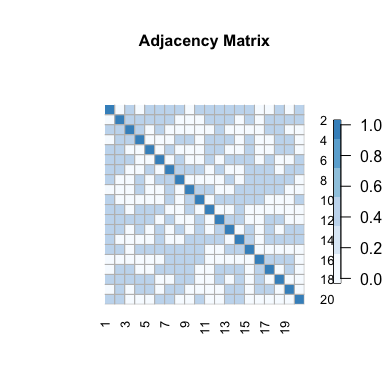

```r
# simulate matrix
n = 20
A.mat = sim_adjacency(n)
A.graph = graph_from_adjacency_matrix(A.mat, mode = "undirected")
graph <- simplify(A.graph, remove.multiple = F)

# plot adjacency matrix
par(cex.main=0.8, par(mar = c(1, 2, 2, 6)))
colors = rep(brewer.pal(9, "Blues"), each = 3)[1:17]
plot.A.mat = A.mat + diag(rep(2, n))    # emphasize diagonal in plot
adj.mat = heatmap.2(plot.A.mat, dendrogram='none', Rowv=FALSE, Colv=FALSE, trace='none',
          key = F, col = as.vector(colors), main = "Adjacency Matrix",
          colsep = 1:n, rowsep = 1:n, sepcolor = "grey", sepwidth=c(0.005,0.005))
image.plot(legend.only=T, zlim=range(0,1), col=colors, legend.mar = 3,
           legend.shrink = 0.5, legend.width = 0.5, legend.cex = 0.3)
```

After computing the degree centrality measure, we can overlay it on the graph like the following, with points with higher centrality score (higher influence) in a brighter color.

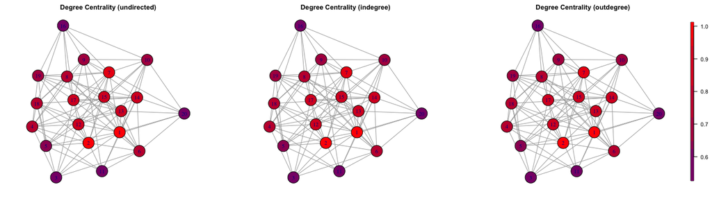

```r
par(mfrow=c(1,3), mar = c(2, 2, 2, 5.1))

# calculate degree centrality:
c.deg.und = centrality::degree(A.mat)
c.deg.in = centrality::degree(A.mat, type = "indegree")
c.deg.out = centrality::degree(A.mat, type = "outdegree")

# plot degree centrality
graph_centrality(graph, c.deg.und, main = "Degree Centrality (undirected)", legend = F)
graph_centrality(graph, c.deg.in, main = "Degree Centrality (indegree)", legend = F)
graph_centrality(graph, c.deg.out, main = "Degree Centrality (outdegree)")
```

We notice both from the visualization of the adjacency matrix and the degree centrality plot that since the edges are generated randomly, there is very little variation in terms of degree centrality (number of nodes they are connected to) for the different nodes. We subsequently calculated the indegree and outdegree centralities separately. We are not surprised to find out that the indegree and outdegree centrality calculations are exactly the same, since our simulated matrix is undirected (thus symmetric).

## Degree Centrality: directed matrix:

We now repeat the same experiment, but on a directed (therefore not symmetric) matrix:

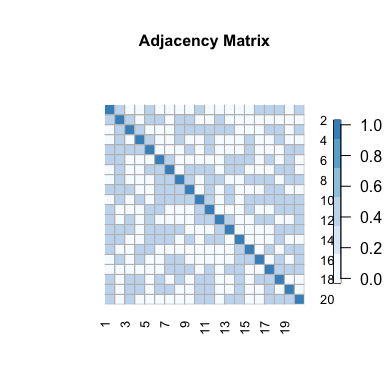

```r
# simulate matrix
n = 20
A.mat = sim_adjacency(n, mode = "directed")
A.graph = graph_from_adjacency_matrix(A.mat, mode = "directed", weighted = TRUE)
graph <- simplify(A.graph, remove.multiple = F)

# plot adjacency matrix
par(cex.main=0.8, par(mar = c(1, 2, 2, 6)))
colors = rep(brewer.pal(9, "Blues"), each = 3)[1:17]
plot.A.mat = A.mat + diag(rep(2, n))    # emphasize diagonal in plot
adj.mat = heatmap.2(plot.A.mat, dendrogram='none', Rowv=FALSE, Colv=FALSE, trace='none',
          key = F, col = as.vector(colors), main = "Adjacency Matrix",
          colsep = 1:n, rowsep = 1:n, sepcolor = "grey", sepwidth=c(0.005,0.005))
image.plot(legend.only=T, zlim=range(0,1), col=colors, legend.mar = 3,
           legend.shrink = 0.5, legend.width = 0.5, legend.cex = 0.3)
```

After computing the degree centrality measure, we can overlay it on the graph like the following, with points with higher centrality score (higher influence) in a brighter color.

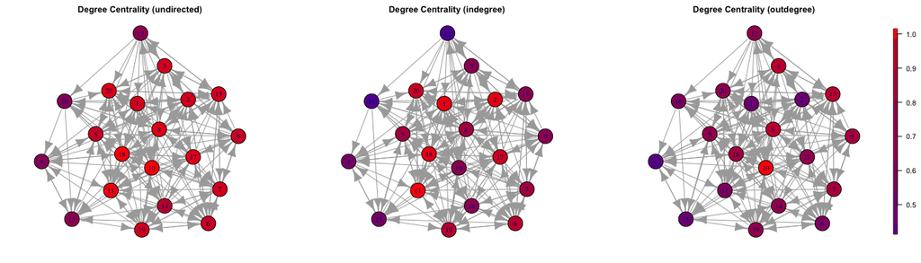

```r
par(mfrow=c(1,3), mar = c(2, 2, 2, 5.1))

# calculate degree centrality:
c.deg.und = centrality::degree(A.mat)
c.deg.in = centrality::degree(A.mat, type = "indegree")
c.deg.out = centrality::degree(A.mat, type = "outdegree")

# plot degree centrality
graph_centrality(graph, c.deg.und, main = "Degree Centrality (undirected)", legend = F)
graph_centrality(graph, c.deg.in, main = "Degree Centrality (indegree)", legend = F)
graph_centrality(graph, c.deg.out, main = "Degree Centrality (outdegree)")
```

We can now observe from the plots above that there is a difference between the indegree, outdegree, and undirectional centralities.

## Degree Centrality: low connectivity vs. high connectivity

Lastly, we compair the centralities on matrices with low vs. high connectivity:

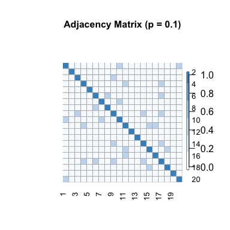

```r
# simulate matrix
n = 20
A.mat.sparse = sim_deg_conn(n, p = 0.1)
A.graph.sparse = graph_from_adjacency_matrix(A.mat.sparse, mode = "undirected")
A.mat.dense = sim_deg_conn(n, p = 0.9)
A.graph.dense = graph_from_adjacency_matrix(A.mat.dense, mode = "undirected")
graph.sparse <- simplify(A.graph.sparse, remove.multiple = F)
graph.dense <- simplify(A.graph.dense, remove.multiple = F)

# plot adjacency matrix
par(cex.main=0.8, par(mar = c(1, 2, 2, 6)), mfrow = c(1,2))
colors = rep(brewer.pal(9, "Blues"), each = 3)[1:17]
plot.A.mat.sparse = A.mat.sparse + diag(rep(2, n))    # emphasize diagonal in plot
plot.A.mat.dense = A.mat.dense + diag(rep(2, n))

adj.mat.s = heatmap.2(plot.A.mat.sparse, dendrogram='none', Rowv=FALSE, Colv=FALSE,
                    trace='none', key = F, col = as.vector(colors),
                    main = "Adjacency Matrix (p = 0.1)", colsep = 1:n, rowsep = 1:n,
                    sepcolor = "grey", sepwidth=c(0.005,0.005))
image.plot(legend.only=T, zlim=range(0,1), col=colors, legend.mar = 3,
           legend.shrink = 0.5, legend.width = 0.5, legend.cex = 0.3)
```

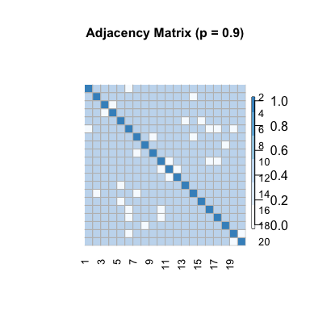

```r
adj.mat.d = heatmap.2(plot.A.mat.dense, dendrogram='none', Rowv=FALSE, Colv=FALSE,
                    trace='none', key = F, col = as.vector(colors),
                    main = "Adjacency Matrix (p = 0.9)", colsep = 1:n, rowsep = 1:n,
                    sepcolor = "grey", sepwidth=c(0.005,0.005))
image.plot(legend.only=T, zlim=range(0,1), col=colors, legend.mar = 3,
           legend.shrink = 0.5, legend.width = 0.5, legend.cex = 0.3)
```

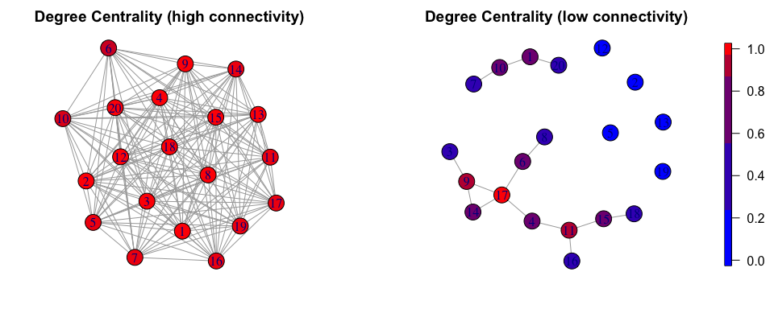

```r
par(mfrow=c(1,2), mar = c(2, 2, 2, 5.1))

# calculate degree centrality:
c.deg.sparse = centrality::degree(A.mat.sparse)
c.deg.dense = centrality::degree(A.mat.dense)

# plot degree centrality
graph_centrality(graph.dense, c.deg.dense,
                 main = "Degree Centrality (high connectivity)", legend = F)
graph_centrality(graph.sparse, c.deg.sparse,
                 main = "Degree Centrality (low connectivity)", legend = T)
```

## Performance Comparison

Here we compare the performance of package *centrality* to the centrality calculations in package *igraph*.

### Accuracy:

We will test for the accuracy of the centrality package by visualizing the results using *igraph* output vs. the results using *centrality* output. The analysis will be performed on the sparse and dense matrices simulated in the section immediately above.

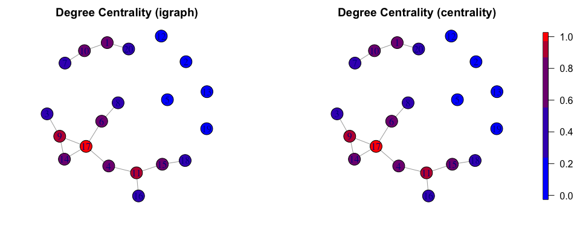

```r
# calculate degree centrality using igraph:
igraph.deg.sparse = centr_degree(A.graph.sparse, normalized = T, loops = F)
ci.deg.s = igraph.deg.sparse$res / max(igraph.deg.sparse$res)
igraph.deg.dense = centr_degree(A.graph.dense, normalized = T, loops = F)
ci.deg.d = igraph.deg.dense$res / max(igraph.deg.dense$res)

# plot: 'centrality' vs 'igraph' on sparse matrix:
par(mfrow=c(1,2), mar = c(2, 2, 2, 5.1))
graph_centrality(graph.sparse, ci.deg.s,
                 main = "Degree Centrality (igraph)", legend = F)
graph_centrality(graph.sparse, c.deg.sparse,
                 main = "Degree Centrality (centrality)", legend = T)
```

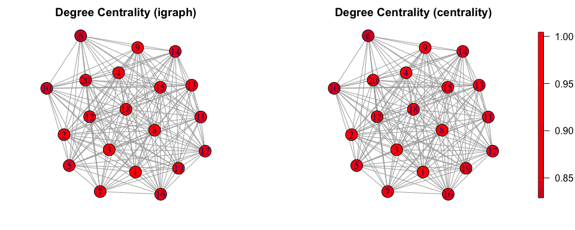

```r
# plot: 'centrality' vs 'igraph' on dense matrix:
par(mfrow=c(1,2), mar = c(2, 2, 2, 5.1))
graph_centrality(graph.dense, ci.deg.d,
                 main = "Degree Centrality (igraph)", legend = F)
graph_centrality(graph.dense, c.deg.dense,
                 main = "Degree Centrality (centrality)", legend = T)
```

### Speed

We will time the speed of overall speed of computing the degree centrality scores of *igraph* and *centrality*. Since the aim of the package is to avoid the tedious graph conversion, we will be including *igraph*’s graph conversion into its total run time. We will also demonstrate their run time differences on large adjacency matrices ($n = 1000$) to see a larger difference.

1. undirected- unweighted- dense matrix

```r
n = 1000
mat.A = sim_deg_conn(n, 0.9)
print("igraph run time: ")
```

```
#> [1] "igraph run time: "
```

```r
system.time({
  graph.A = graph_from_adjacency_matrix(mat.A, mode = "undirected")
  igraph.deg = centr_degree(graph.A, normalized = T, loops = F)
  ci.deg = igraph.deg$res / max(igraph.deg$res)
})
```

```
#>    user  system elapsed
#>   0.053   0.012   0.066
```

```r
print("centrality run time:" )
```

```
#> [1] "centrality run time:"
```

```r
system.time({
  c.deg = centrality::degree(mat.A)
})
```

```
#>    user  system elapsed
#>   0.119   0.008   0.129
```

2. undirected- unweighted- sparse matrix

```r
mat.B = sim_deg_conn(n, 0.1)
print("igraph run time: ")
```

```
#> [1] "igraph run time: "
```

```r
system.time({
  graph.B = graph_from_adjacency_matrix(mat.B, mode = "undirected")
  igraph.deg = centr_degree(graph.B, normalized = T, loops = F)
  ci.deg = igraph.deg$res / max(igraph.deg$res)
})
```

```
#>    user  system elapsed
#>   0.010   0.002   0.013
```

```r
print("centrality run time:" )
```

```
#> [1] "centrality run time:"
```

```r
system.time({
  c.deg = centrality::degree(mat.B)
})
```

```
#>    user  system elapsed
#>   0.034   0.007   0.042
```

3. directed- unweighted matrix

```r
mat.C = sim_adjacency(n, mode = "directed")
print("igraph run time: ")
```

```
#> [1] "igraph run time: "
```

```r
system.time({
  graph.C = graph_from_adjacency_matrix(mat.C, mode = "directed")
  igraph.deg = centr_degree(graph.C, normalized = T, loops = F)
  ci.deg = igraph.deg$res / max(igraph.deg$res)
})
```

```
#>    user  system elapsed
#>   0.058   0.009   0.068
```

```r
print("centrality run time:" )
```

```
#> [1] "centrality run time:"
```

```r
system.time({
  c.deg = centrality::degree(mat.C)
})
```

```
#>    user  system elapsed
#>   0.032   0.004   0.036
```

4. directed- weighted matrix

```r
mat.D = sim_adjacency(n, mode = "directed", weight = c(1, 100))
print("igraph run time: ")
```

```
#> [1] "igraph run time: "
```

```r
system.time({
  graph.D = graph_from_adjacency_matrix(mat.D, mode = "directed", weighted = T)
  igraph.deg = centr_degree(graph.D, normalized = T, loops = F)
  ci.deg = igraph.deg$res / max(igraph.deg$res)
})
```

```
#>    user  system elapsed
#>   0.130   0.036   0.168
```

```r
print("centrality run time:" )
```

```
#> [1] "centrality run time:"
```

```r
system.time({
  c.deg = centrality::degree(mat.D)
})
```

```
#>    user  system elapsed
#>   0.121   0.014   0.142
```